# Supervised Learning - Foundations: ReCell

### Let's check if multicollinearity is still present in the data.

```python
# to check VIF numbers
vif_series2 = pd.Series(
    [variance_inflation_factor(x_train.values, i) for i in range(x_train.shape[1])],
    index=x_train.columns,
)
print("VIF values: \n\n{}\n".format(vif_series2))
```

```
VIF values:

const                            738.428397
ram                                2.042906
days_used                          1.798308
screen_size_log                    6.419613
main_camera_mp_log                 2.633657
selfie_camera_mp_log               3.577787
int_memory_log                     1.704313
battery_log                        4.385510
weight_log                         5.191842
new_price_log                      2.671357
os_Others                          1.748628
os_Windows                         1.024953
os_iOS                             1.092599
4g_yes                             2.088492
5g_yes                             1.724393
brand_name_bin_medium_device       1.185006
brand_name_bin_premium_device      1.036699
dtype: float64
```

- 'screen_size_log' has IVF at 6.4196 and 'weight_log'.
- Let's see the effect of dropping 'screen_size_log'.

```python
# to droup a column
x_train = x_train.drop(["screen_size_log"], axis=1)
```

```python
vif_series3 = pd.Series(
    [variance_inflation_factor(x_train.values, i) for i in range(x_train.shape[1])],
    index=x_train.columns,
)
print("VIF values: \n\n{}\n".format(vif_series3))
```

```
VIF values:

const                            676.717347
ram                                2.042185
days_used                          1.755503
main_camera_mp_log                 2.585532
selfie_camera_mp_log               3.553743
int_memory_log                     1.704272
battery_log                        4.076708
weight_log                         2.962563
new_price_log                      2.670922
os_Others                          1.388554
os_Windows                         1.024923
os_iOS                             1.091734
4g_yes                             2.087586
5g_yes                             1.723854
brand_name_bin_medium_device       1.184990
brand_name_bin_premium_device      1.036425
dtype: float64
```

- Now all columns has VIF less than 5. We will keep this model.

```python
# To check the lastest model
olsmod_5 = sm.OLS(y_train, x_train)
olsres_5 = olsmod_5.fit()
print(olsres_5.summary())
```

```
                            OLS Regression Results
==============================================================================
Dep. Variable:         used_price_log   R-squared:                       0.844
Model:                            OLS   Adj. R-squared:                  0.843
Method:                 Least Squares   F-statistic:                     866.0
Date:                Sun, 12 Dec 2021   Prob (F-statistic):               0.00
Time:                        04:14:06   Log-Likelihood:                 160.81
No. Observations:                2417   AIC:                            -289.6
Df Residuals:                    2401   BIC:                            -197.0
Df Model:                          15
Covariance Type:            nonrobust
=================================================================================================
                                    coef    std err          t      P>|t|      [0.025      0.975]
-------------------------------------------------------------------------------------------------
const                            -0.6991      0.120     -5.816      0.000      -0.935      -0.463
ram                               0.0159      0.005      3.328      0.001       0.007       0.025
days_used                     -7.988e-05   2.45e-05     -3.258      0.001      -0.000   -3.18e-05
main_camera_mp_log                0.1714      0.013     12.794      0.000       0.145       0.198
selfie_camera_mp_log              0.1526      0.010     15.701      0.000       0.134       0.172
int_memory_log                    0.0120      0.007      1.816      0.070      -0.001       0.025
battery_log                       0.0102      0.023      0.444      0.657      -0.035       0.055
weight_log                        0.4618      0.023     20.140      0.000       0.417       0.507
new_price_log                     0.3654      0.011     32.686      0.000       0.343       0.387
os_Others                        -0.0044      0.028     -0.159      0.873      -0.059       0.050
os_Windows                        0.0209      0.035      0.590      0.555      -0.049       0.090
os_iOS                           -0.0673      0.044     -1.543      0.123      -0.153       0.018
4g_yes                            0.0333      0.014      2.334      0.020       0.005       0.061
5g_yes                            0.0195      0.030      0.648      0.517      -0.039       0.078
brand_name_bin_medium_device      0.2917      0.039      7.399      0.000       0.214       0.369
brand_name_bin_premium_device     0.5915      0.164      3.616      0.000       0.271       0.912
==============================================================================
Omnibus:                      166.892   Durbin-Watson:                   1.940
Prob(Omnibus):                  0.000   Jarque-Bera (JB):              300.807
Skew:                          -0.500   Prob(JB):                     4.79e-66
Kurtosis:                       4.409   Cond. No.                     2.55e+04
==============================================================================

Notes:
[1] Standard Errors assume that the covariance matrix of the errors is correctly specified.
[2] The condition number is large, 2.55e+04. This might indicate that there are
strong multicollinearity or other numerical problems.
```

- The 'olsmod_5' model has R-squared 0.844 and Adj. R-squared 0.843.

## Checking Linear Regression Assumptions

- In order to make statistical inferences from a linear regression model, it is important to ensure that the assumptions of linear regression are satisfied.

For Linear Regression, we need to check if the following assumptions hold:-

1. Linearity
2. Independence
3. Homoscedasticity
4. Normality of error terms
5. No strong Multicollinearity

### Checking Linearity

```python
import pandas as pd

df_pred = pd.DataFrame()

df_pred["Actual Values"] = y_train.values.flatten()  # actual values
df_pred["Fitted Values"] = olsres_5.fittedvalues.values  # predicted values
df_pred["Residuals"] = olsres_5.resid.values  # residuals

df_pred.head() # to return the fist 5 rows
```

|  | Actual Values | Fitted Values | Residuals |
| --- | --- | --- | --- |
| 0 | 4.104130 | 3.796233 | 0.307897 |
| 1 | 4.460029 | 4.693907 | -0.233878 |
| 2 | 4.328626 | 4.385796 | -0.057170 |
| 3 | 4.295788 | 4.344798 | -0.049010 |
| 4 | 4.467975 | 4.534776 | -0.066801 |

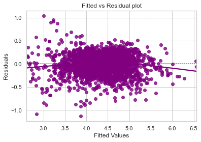

```python
# let us plot the fitted values vs residuals
sns.set_style("whitegrid")
sns.residplot(
    data=df_pred, x="Fitted Values", y="Residuals", color="purple", lowess=True
)
plt.xlabel("Fitted Values") # to lable x-axis
plt.ylabel("Residuals") # to lable y-axis
plt.title("Fitted vs Residual plot") # to lable the title of the graph
plt.show()
```

- We can observe that there is no pattern in the residual vs fitted values. We say that this model is linear.

### Test for Normality

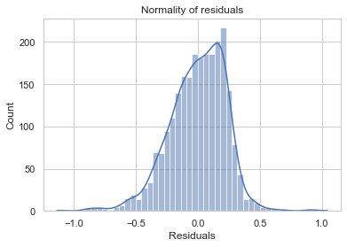

```python
# to plot histogram
sns.histplot(df_pred["Residuals"], kde=True)
plt.title("Normality of residuals") # to lable title
plt.show()
```

- The residuals is almost normality.

**The QQ plot of residuals can be used to visually check the normality assumption. The normal probability plot of residuals should approximately follow a straight line.**

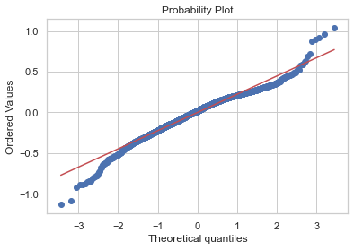

```python
# to import pylab package
import pylab
import scipy.stats as stats

#to return QQ plot
stats.probplot(df_pred["Residuals"], dist="norm", plot=pylab)
plt.show()
```

- Most of the points are lying on the straight line in QQ plot

### Test for Homoscedasity

```python
# to import a package
import statsmodels.stats.api as sms
from statsmodels.compat import lzip
```

The null and alternate hypotheses of the goldfeldquandt test are as follows:

- Null hypothesis : Residuals are homoscedastic
- Alternate hypothesis : Residuals have hetroscedasticity

```python
# to chech the p-value for residules
name = ["F statistic", "p-value"]
test = sms.het_goldfeldquandt(df_pred["Residuals"], x_train)
lzip(name, test)
```

```
[('F statistic', 1.085908892708136), ('p-value', 0.07738650909206692)]
```

- Since p-value > 0.05 we can say that the residuals are homoscedastic.

*All the assumptions of linear regression are now satisfied.*

## Final Model Summary

```python
# to return a summary page of the last linear model
print(olsres_5.summary())
```

```
                            OLS Regression Results
==============================================================================
Dep. Variable:         used_price_log   R-squared:                       0.844
Model:                            OLS   Adj. R-squared:                  0.843
Method:                 Least Squares   F-statistic:                     866.0
Date:                Sun, 12 Dec 2021   Prob (F-statistic):               0.00
Time:                        04:14:08   Log-Likelihood:                 160.81
No. Observations:                2417   AIC:                            -289.6
Df Residuals:                    2401   BIC:                            -197.0
Df Model:                          15
Covariance Type:            nonrobust
=================================================================================================
                                    coef    std err          t      P>|t|      [0.025      0.975]
-------------------------------------------------------------------------------------------------
const                            -0.6991      0.120     -5.816      0.000      -0.935      -0.463
ram                               0.0159      0.005      3.328      0.001       0.007       0.025
days_used                     -7.988e-05   2.45e-05     -3.258      0.001      -0.000   -3.18e-05
main_camera_mp_log                0.1714      0.013     12.794      0.000       0.145       0.198
selfie_camera_mp_log              0.1526      0.010     15.701      0.000       0.134       0.172
int_memory_log                    0.0120      0.007      1.816      0.070      -0.001       0.025
battery_log                       0.0102      0.023      0.444      0.657      -0.035       0.055
weight_log                        0.4618      0.023     20.140      0.000       0.417       0.507
new_price_log                     0.3654      0.011     32.686      0.000       0.343       0.387
os_Others                        -0.0044      0.028     -0.159      0.873      -0.059       0.050
os_Windows                        0.0209      0.035      0.590      0.555      -0.049       0.090
os_iOS                           -0.0673      0.044     -1.543      0.123      -0.153       0.018
4g_yes                            0.0333      0.014      2.334      0.020       0.005       0.061
5g_yes                            0.0195      0.030      0.648      0.517      -0.039       0.078
brand_name_bin_medium_device      0.2917      0.039      7.399      0.000       0.214       0.369
brand_name_bin_premium_device     0.5915      0.164      3.616      0.000       0.271       0.912
==============================================================================
Omnibus:                      166.892   Durbin-Watson:                   1.940
Prob(Omnibus):                  0.000   Jarque-Bera (JB):              300.807
Skew:                          -0.500   Prob(JB):                     4.79e-66
Kurtosis:                       4.409   Cond. No.                     2.55e+04
==============================================================================

Notes:
[1] Standard Errors assume that the covariance matrix of the errors is correctly specified.
[2] The condition number is large, 2.55e+04. This might indicate that there are
strong multicollinearity or other numerical problems.
```